# Tutorial5: Selección de modelo de reloj

Sandra Reinales & Gustavo Ballen

En `MCMCTree` la selección del modelo de reloj molecular usado para inferencia de tiempos de divergencia de un linaje se lleva a cabo mediante la estimación de la **probabilidad marginal de cada modelo**, y luego, calculando el factor de Bayes o probabilidad posterior del mismo (i.e. selección bayesiana del modelo de reloj).

`MCMCTree` implementa tres modelos de reloj: el modelo de movimiento browniano geométrico (`GBM`), el modelo log-normal independiente (`ILN`) y el modelo de reloj estricto (`CLK`) [^1].

Este tutorial está basado en el tutorial de Mario dos Reis, disponible [aquí](https://dosreislab.github.io/2017/10/24/marginal-likelihood-mcmc3r.html).

### Preparar el directorio para el análisis de reloj estricto

Vamos a crear un directorio nuevo y allí vamos a copiar el *control file* y el archivo `in.BV` que acabamos de obtener producto del análisis de verosimilitud aproximada.

En terminal:

```bash
mkdir -p clk
cp data/mcmctree.ctl clk/
```

Ahora tenemos que editar el *control file* para usar `usedata=2` con el fin de usar el gradiente y matriz hessiana (`in.BV`) y `clock=1` que significa reloj estricto (*strict clock* - CLK). Es posible agregar la ruta al archivo `in.BV` en vez de copiarlo en cada una de los directorios.

Un paso más adelante el paquete `mcmc3r` va a crear un sistema de directorios y va a copiar el *control file* entonces tenemos que ajustar la ruta a los archivos de entrada (i.e. árbol inicial y la matriz con los alineamientos) para que `MCMCtree` los pueda encontrar.

```bash
cd clk

## Definir usedata
sed -r -i 's/usedata = 0/usedata = 2 ..\/..\/approximate\/in.BV/g' mcmctree.ctl

## Definir ruta para los archivos de datos
sed -r -i 's/seqfile = ..\/data\/concatenated.phylip/seqfile = ..\/..\/data\/concatenated.phylip/g' mcmctree.ctl

sed -r -i 's/treefile = ..\/data\/startingTree.phy/treefile = ..\/..\/data\/startingTree.phy/g' mcmctree.ctl

## Podemos usar un lector/editor de texto para revisar el contenido del archivo
less mcmctree.ctl
nano mcmctree.ctl
```

Usando el paquete de R `mcmc3r` seleccionaremos 4 puntos `b` para estimar la probabilidad marginal del reloj estricto utilizando el método de pasos (*stepping stones*). Idealmente debemos correr muchas más *stones*, por ejemplo, **64 *stones* para estimar con mayor precisión la verosimilitud marginal de cada modelo**.

En `R` vamos a correr lo siguiente:

```r
library(mcmc3r)

## Revisar el directorio de trabajo
getwd()

## En caso de que no sea clk, vamos a definirlo
setwd("clk")

## Definir los valores de los pasos
b <- mcmc3r::make.beta(n=4, a=5, method="step-stones")

## Crear los directorios utilizando el archivo de control mcmctree.ctl
mcmc3r::make.bfctlf(b, ctlf="mcmctree.ctl", betaf="beta.txt")
```

Ahora vamos a correr el análisis en cada una de los directorios que acabamos de crear. Podemos usar un *loop* de `Bash`, o visitar cada directorio y ejecutar `mcmctree` uno por uno.

```bash
for d in `seq 1 1 4`; do cd $d; mcmctree; cd ..; done
```

### Preparar los directorios para el análisis del modelo independiente y el modelo autocorrelacionado

Vamos de nuevo a la terminal para crear dos directorios adicionales usando `Bash`, uno para el modelo independiente (ILN) y otro para el modelo autocorrelacionado (GBM).

```bash
cd ..
mkdir -p iln gbm

## Copiemos el control file
cp data/mcmctree.ctl iln/
cp data/mcmctree.ctl gbm/
```

Necesitamos modificar el modelo de reloj en el *control file* para cada directorio, cambiando `clock=2` para `ILN` y `clock=3` para `GBM`.

```bash
cd iln

## Definir usedata
sed -r -i 's/usedata = 0/usedata = 2 ..\/..\/approximate\/in.BV/g' mcmctree.ctl

## Definir clock
sed -r -i 's/clock = 1/clock = 2/g' mcmctree.ctl

## Definir ruta para los archivos de datos
sed -r -i 's/seqfile = ..\/data\/concatenated.phylip/seqfile = ..\/..\/data\/concatenated.phylip/g' mcmctree.ctl

sed -r -i 's/treefile = ..\/data\/startingTree.phy/treefile = ..\/..\/data\/startingTree.phy/g' mcmctree.ctl
```

```bash
cd ../gbm

## Definir usedata
sed -r -i 's/usedata = 0/usedata = 2 ..\/..\/approximate\/in.BV/g' mcmctree.ctl

## Definir clock
sed -r -i 's/clock = 1/clock = 3/g' mcmctree.ctl

## Definir ruta para los archivos de datos
sed -r -i 's/seqfile = ..\/data\/concatenated.phylip/seqfile = ..\/..\/data\/concatenated.phylip/g' mcmctree.ctl

sed -r -i 's/treefile = ..\/data\/startingTree.phy/treefile = ..\/..\/data\/startingTree.phy/g' mcmctree.ctl
```

Ahora volvamos a `R` para que podamos preparar las *stones* y los directorios para cada uno de los modelos adicionales.

```r
## b ya fue calculado asumiendo que esta cargado en el ambiente de trabajo
## caso contrario, calcularlo nuevamente
## asumiendo que estamos en gbm
## Preparar template para ILN:
setwd("../iln")
mcmc3r::make.bfctlf(b, ctlf="mcmctree.ctl", betaf="beta.txt")

# prepare templates for GBM:
setwd("../gbm")
mcmc3r::make.bfctlf(b, ctlf="mcmctree.ctl", betaf="beta.txt")
```

Ahora ejecutemos el análisis, ya sea con el `loop` o manualmente:

```bash
## Asumiendo que estamos en el directorio principal del repositorio
cd iln; for d in `seq 1 1 4`; do cd $d; mcmctree; cd ..; done
cd ..

cd gbm; for d in `seq 1 1 4`; do cd $d; mcmctree; cd ..; done
cd ..
```

### Leámos los resultados de cada uno de los modelos de reloj usando `mcmc3r`

Vamos a `R`

```r
## Leer los valores de log-verosimilitud  de cada stone y calcular la log-verosimilitud marginal

## Asumiendo que estamos en el directorio principal del repositorio
setwd("clk")
clk <- mcmc3r::stepping.stones()

setwd("../iln")
iln <- mcmc3r::stepping.stones()

setwd("../gbm")
gbm <- mcmc3r::stepping.stones()

## Resumir los resultados
tmod <- data.frame(model=c("CLK","ILN","GBM"),
                   logml=c(clk$logml, iln$logml, gbm$logml),
                   se=c(clk$se, iln$se, gbm$se))
print(tmod)
```

```
##   model      logml       se
## 1   CLK -1038.6585 1.321273
## 2   ILN  -698.5468 1.342083
## 3   GBM  -722.5293 1.360166
```

Lo ideal es que el error estándar (`E.S.`) sea mucho menor que la diferencia de verosimilitud marginal logarítmica entre los modelos que se están probando. Es posible reducir el `E.S.` aumentando `nsample` o `samplefreq` en el *control file*. Sin embargo, es importante tener en cuenta que para reducir el `E.S.` a la mitad, es necesario cuadruplicar el valor de `nsample`, lo que puede requerir un mayor esfuerzo computacional.

Las probabilidades posteriores se calculan asumiendo *priors* de modelo iguales. Por tanto, el modelo `ILN` tiene la mayor verosimilitud logarítmica marginal, y consecuentemente la mayor probabilidad posterior.

### Usar Bayes Factors para seleccionar el modelo

```r
## Ahora vamos a calcular el Bayes Factor para seleccionar el modelo
results <-  mcmc3r::bayes.factors(clk, iln, gbm)

## Explorar el output
print(results)
```

```
## $bf
## [1] 1.955902e-148  1.000000e+00  3.841699e-11
##
## $logbf
## [1] -340.11174    0.00000  -23.98252
##
## $pr
## [1] 1.955902e-148  1.000000e+00  3.841699e-11
##
## $prior
## [1] 0.3333333 0.3333333 0.3333333
##
## $pr.ci
##               2.5%         97.5%
## [1,] 4.806363e-150 8.197832e-147
## [2,]  1.000000e+00  1.000000e+00
## [3,]  8.798345e-13  1.491542e-09
```

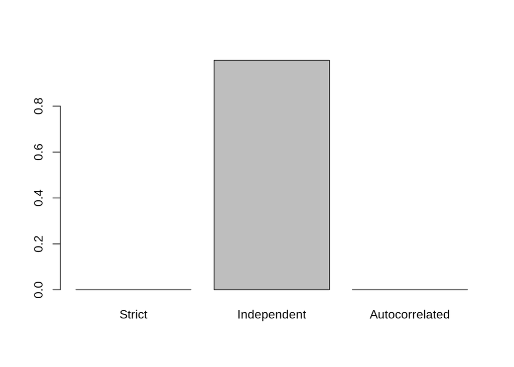

```r
## Graficar la probabilidad posterior de cada modelo
barplot(results$pr, names.arg=c("Strict", "Independent", "Autocorrelated"))
```

### Referencias

[^1]: Rannala, B. and Yang, Z., 2007. Inferring speciation times under an episodic molecular clock. Systematic biology, 56(3), pp.453-466.